# PracticalMachineLearning_ROBMILL_Mac

### Final Peer Reviewed Assignment

## Practical Machine Learning

## Week 4

# Synopsis

Data source for reproducibility: 1. http://groupware.les.inf.puc-rio.br/har 2. http://groupware.les.inf.puc-rio.br/har#weight_lifting_exercises

The data set describes quality of execution for the device wearer while doing dumbbell lift exercises.

There are 5 different classes representing execution quality. Class A represents an example of successful execution of the exercise while Classes B-E represent examples of common mistakes made.

- Class A: exactly according to specification.
- Class B: throwing the elbows to the front.
- Class C: lifting the dumbell only halfway.
- Class D: lowering dumbell only halfway.
- Class E: throwing the hips to the front.

### The goal of the exercise is to identify predictors that accurately determine execution quality or manner of exercise.

1. Naive Bayes: to act as a benchmark for classification performance.
2. Classification Trees: EDA presents some break opportunities for total_accel features that may lend themselves to a classification tree algorithm.
3. Boosted Machine (GBM): run against data to test for a more accurate modeling approach.

### Initial EDA on Raw Data Set

```r
dim(exerciseData) # display number or rows/columns
```

```
## [1] 19622   160
```

```r
head(exerciseData) # display first few rows
```

```
##   X user_name raw_timestamp_part_1 raw_timestamp_part_2   cvtd_timestamp
## 1 1  carlitos           1323084231               788290 05/12/2011 11:23
## 2 2  carlitos           1323084231               808298 05/12/2011 11:23
## 3 3  carlitos           1323084231               820366 05/12/2011 11:23
## 4 4  carlitos           1323084232               120339 05/12/2011 11:23
## 5 5  carlitos           1323084232               196328 05/12/2011 11:23
## 6 6  carlitos           1323084232               304277 05/12/2011 11:23
##   new_window num_window roll_belt pitch_belt yaw_belt total_accel_belt
## 1         no         11      1.41       8.07    -94.4                3
## 2         no         11      1.41       8.07    -94.4                3
## 3         no         11      1.42       8.07    -94.4                3
## 4         no         12      1.48       8.05    -94.4                3
## 5         no         12      1.48       8.07    -94.4                3
## 6         no         12      1.45       8.06    -94.4                3
##   kurtosis_roll_belt kurtosis_picth_belt kurtosis_yaw_belt
```

[output cut: 265 more lines]

```r
table(exerciseData$classe) # display a table using classe
```

```
##
##    A    B    C    D    E
## 5580 3797 3422 3216 3607
```

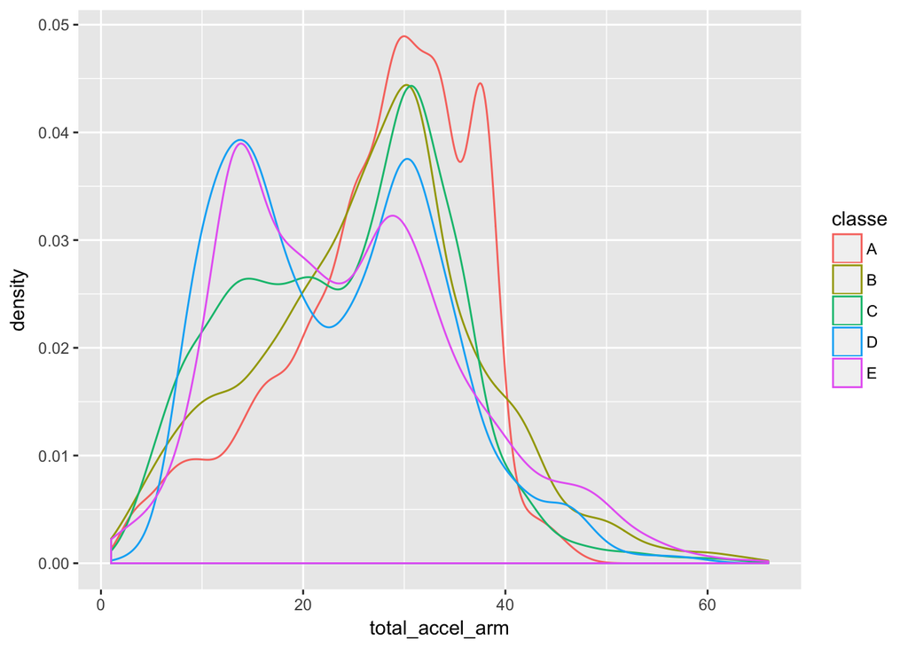

```r
# Density plots
qplot(total_accel_arm,colour=classe,
      data=exerciseData, geom="density")
```

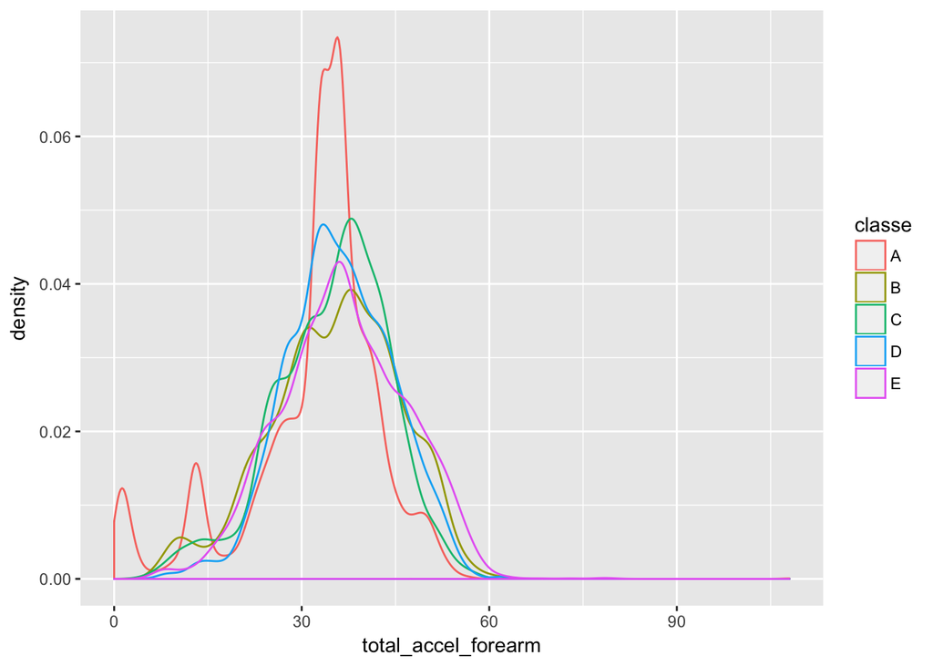

```r
qplot(total_accel_forearm,colour=classe,
      data=exerciseData,geom="density")
```

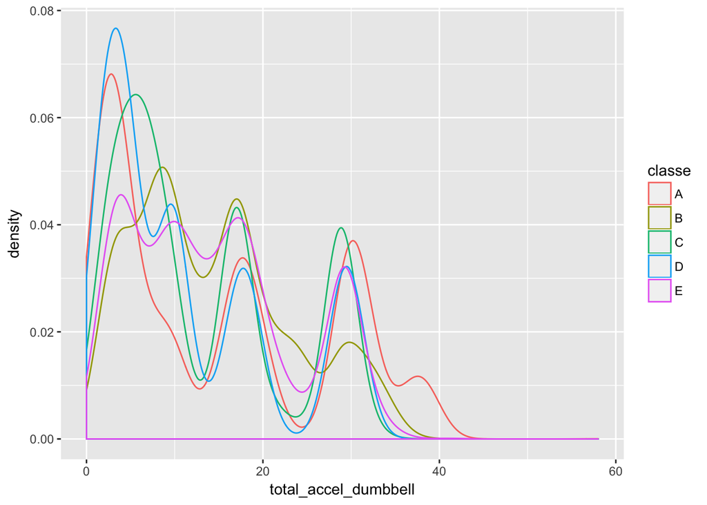

```r
qplot(total_accel_dumbbell,colour=classe,
      data=exerciseData, geom="density")
```

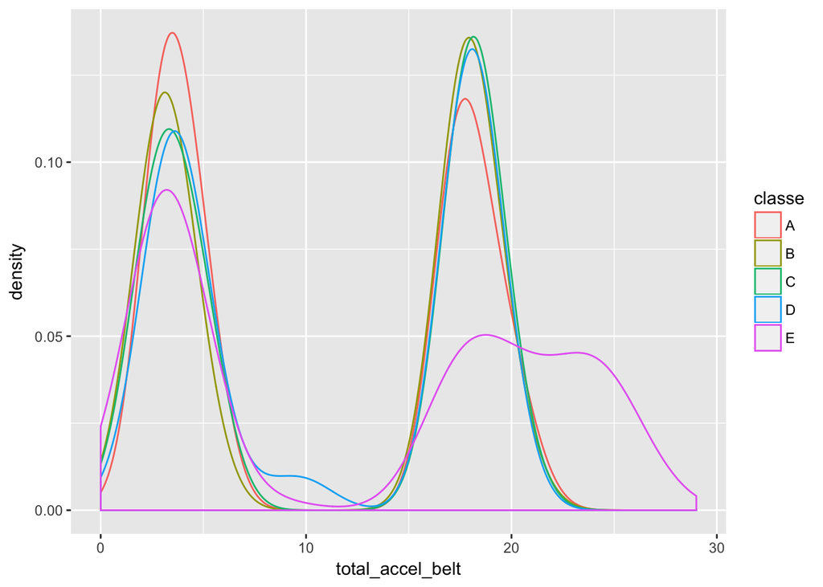

```r
qplot(total_accel_belt,colour=classe,
      data=exerciseData, geom="density")
```

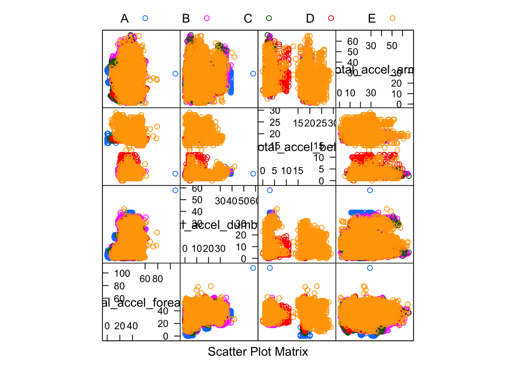

```r
featurePlot(x=exerciseData[,c("total_accel_forearm","total_accel_dumbbell","total_accel_belt","total_accel_arm")],
            y=exerciseData$classe,
            plot="pairs",
            auto.key=list(columns = 5))
```

### Partition exerciseData Data and Pre-processing

```r
  InputDf  <- exerciseData  # cleanse the Training Dataframe
#   Step 1. Remove Variables containing missing or NA values.
    InputDf <- exerciseData
    Step01  <- InputDf[, colSums(is.na(InputDf)) == 0]
    dim(Step01)
```

```
## [1] 19622    60
```

```r
#   Step 2. Remove timestamp and window variables that do not describe accelerometer measurements
    target  <- grepl("^X|timestamp|window", names(Step01))
    Step02  <- Step01[, !target]

#   Step 3. Coerce accelerometer measurements (variables) to be numeric
    classe        <- Step02$classe   #Preserve the classe (factor) variable
    Step03        <- Step02[, sapply(Step02, is.numeric)]
    Step03$classe <- classe   #Join classe to the remaining dataset
    exerciseData   <- Step03

  InputDf  <- validation # cleanse the Testing Dataframe (using the same steps)
#   Step 1. Remove Variables containing missing or NA values.
    Step01  <- InputDf[, colSums(is.na(InputDf)) == 0]

#   Step 2. Remove timestamp and window variables that do not describe accelerometer measurements
    target  <- grepl("^X|timestamp|window", names(Step01))
    Step02  <- Step01[, !target]

#   Step 3. Coerce accelerometer measurements (variables) to be numeric - classe doesn't exist in test
    Step03  <- Step02[, sapply(Step02, is.numeric)]
    validation  <- Step03



inTrain<-createDataPartition(exerciseData$classe,
                             p=0.80,
                             list=FALSE)


training<-exerciseData[inTrain,]
testing<-exerciseData[-inTrain,]

# Display number of rows and columnts
# in training and testing data sets
dim(training)
```

```
## [1] 15699    53
```

```r
dim(testing)
```

```
## [1] 3923   53
```

```r
dim(validation)
```

```
## [1] 20 53
```

```r
# Set some alternate Cross-Validation Methods
fitControl <- trainControl(method = "cv", number=3)
fitControl
```

[output not shown]

[output cut: 59 more lines]

[output not shown]

```r
# Print accuracy measurements
confusionMatrix(predictions.NB$class,testing$classe)
```

```
## Confusion Matrix and Statistics
##
##           Reference
## Prediction   A   B   C   D   E
##          A 315  26  15   0   7
##          B  98 478  68  33 156
##          C 509 155 471 233 105
##          D 158  52 100 305  95
##          E  36  48  30  72 358
##
## Overall Statistics
##
##                Accuracy : 0.4912
##                  95% CI : (0.4754, 0.507)
##     No Information Rate : 0.2845
##     P-Value [Acc > NIR] : < 2.2e-16
##
##                   Kappa : 0.3734
##  Mcnemar's Test P-Value : < 2.2e-16
##
## Statistics by Class:
##
##                      Class: A Class: B Class: C Class: D Class: E
## Sensitivity           0.28226   0.6298   0.6886  0.47434  0.49653
## Specificity           0.98290   0.8878   0.6906  0.87652  0.94191
## Pos Pred Value        0.86777   0.5738   0.3198  0.42958  0.65809
## Neg Pred Value        0.77500   0.9091   0.9131  0.89480  0.89257
## Prevalence            0.28448   0.1935   0.1744  0.16391  0.18379
## Detection Rate        0.08030   0.1218   0.1201  0.07775  0.09126
## Detection Prevalence  0.09253   0.2123   0.3755  0.18098  0.13867
## Balanced Accuracy     0.63258   0.7588   0.6896  0.67543  0.71922
```

### Classification Tree using a Boosting cross-validation TrainControl

```r
# Predict using CT model
predictions.rpart<-predict(modFit.rpart,testing)
```

```r
# Print accuracy measurements
confusionMatrix(predictions.rpart,testing$classe)
```

```
## Confusion Matrix and Statistics
##
##           Reference
## Prediction   A   B   C   D   E
##          A 999 298 311 308 113
##          B  30 288  27 117  97
##          C  84 173 346 218 200
##          D   0   0   0   0   0
##          E   3   0   0   0 311
##
## Overall Statistics
##
##                Accuracy : 0.4955
##                  95% CI : (0.4798, 0.5113)
##     No Information Rate : 0.2845
##     P-Value [Acc > NIR] : < 2.2e-16
##
##                   Kappa : 0.3408
##  Mcnemar's Test P-Value : NA
##
## Statistics by Class:
##
##                      Class: A Class: B Class: C Class: D Class: E
## Sensitivity            0.8952  0.37945   0.5058   0.0000  0.43135
## Specificity            0.6331  0.91435   0.7916   1.0000  0.99906
## Pos Pred Value         0.4924  0.51521   0.3389      NaN  0.99045
## Neg Pred Value         0.9382  0.85999   0.8835   0.8361  0.88640
## Prevalence             0.2845  0.19347   0.1744   0.1639  0.18379
## Detection Rate         0.2547  0.07341   0.0882   0.0000  0.07928
## Detection Prevalence   0.5172  0.14249   0.2603   0.0000  0.08004
## Balanced Accuracy      0.7641  0.64690   0.6487   0.5000  0.71520
```

### Run a Boosting Algorithm against all features

### GBM Confusion Matrix

```r
confusionMatrix(predictions.boost,testing$classe)
```

```
## Confusion Matrix and Statistics
##
##           Reference
## Prediction    A    B    C    D    E
##          A 1104   14    0    0    1
##          B    8  721   19    4   13
##          C    2   23  656   27    9
##          D    2    1    9  605    9
##          E    0    0    0    7  689
##
## Overall Statistics
##
##                Accuracy : 0.9623
##                  95% CI : (0.9558, 0.968)
##     No Information Rate : 0.2845
##     P-Value [Acc > NIR] : < 2.2e-16
##
##                   Kappa : 0.9523
##  Mcnemar's Test P-Value : 1.649e-05
##
## Statistics by Class:
##
##                      Class: A Class: B Class: C Class: D Class: E
## Sensitivity            0.9892   0.9499   0.9591   0.9409   0.9556
## Specificity            0.9947   0.9861   0.9812   0.9936   0.9978
## Pos Pred Value         0.9866   0.9425   0.9149   0.9665   0.9899
## Neg Pred Value         0.9957   0.9880   0.9913   0.9885   0.9901
## Prevalence             0.2845   0.1935   0.1744   0.1639   0.1838
## Detection Rate         0.2814   0.1838   0.1672   0.1542   0.1756
## Detection Prevalence   0.2852   0.1950   0.1828   0.1596   0.1774
## Balanced Accuracy      0.9920   0.9680   0.9701   0.9672   0.9767
```

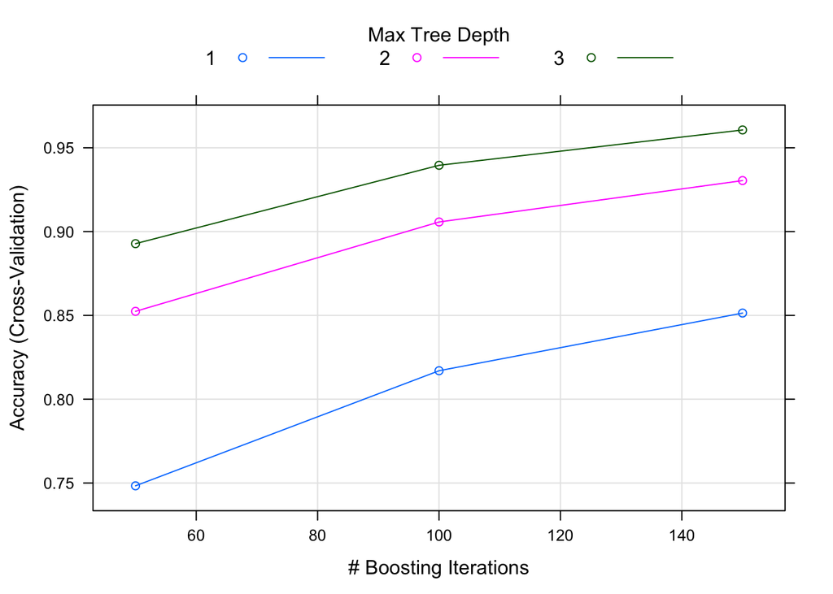

```r
plot(modFit.boost)
```

### Running a Random Forest model against all features

### Randdom Forest Confustion Matrix

```r
# Cross-validated data
confusionMatrix(predictions.boost2,testing$classe)
```

```
## Confusion Matrix and Statistics
##
##           Reference
## Prediction    A    B    C    D    E
##          A 1115    3    0    0    0
##          B    1  756    4    0    0
##          C    0    0  680   10    0
##          D    0    0    0  633    0
##          E    0    0    0    0  721
##
## Overall Statistics
##
##                Accuracy : 0.9954
##                  95% CI : (0.9928, 0.9973)
##     No Information Rate : 0.2845
##     P-Value [Acc > NIR] : < 2.2e-16
##
##                   Kappa : 0.9942
##  Mcnemar's Test P-Value : NA
##
## Statistics by Class:
##
##                      Class: A Class: B Class: C Class: D Class: E
## Sensitivity            0.9991   0.9960   0.9942   0.9844   1.0000
## Specificity            0.9989   0.9984   0.9969   1.0000   1.0000
## Pos Pred Value         0.9973   0.9934   0.9855   1.0000   1.0000
## Neg Pred Value         0.9996   0.9991   0.9988   0.9970   1.0000
## Prevalence             0.2845   0.1935   0.1744   0.1639   0.1838
## Detection Rate         0.2842   0.1927   0.1733   0.1614   0.1838
## Detection Prevalence   0.2850   0.1940   0.1759   0.1614   0.1838
## Balanced Accuracy      0.9990   0.9972   0.9955   0.9922   1.0000
```

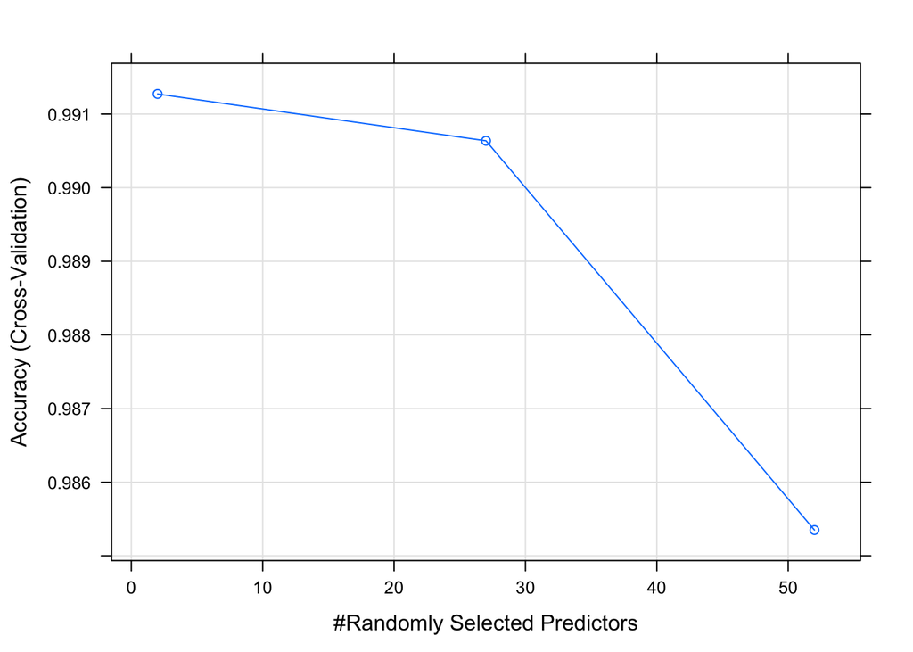

```r
plot(modFit.boost2)
```

```r
validation$classe<-predict(modFit.boost,newdata=validation)

print(validation$classe)
```

```
##  [1] B A B A A E D B A A B C B A E E A B B B
## Levels: A B C D E
```

```r
write.csv(validation,file = "exprediction.csv")

validation$classe<-predict(modFit.boost2,newdata=validation)

print(validation$classe)
```

```
##  [1] B A B A A E D B A A B C B A E E A B B B
## Levels: A B C D E
```

```r
write.csv(validation,file="rfprediction.csv")
```

## Citation

Velloso, E.; Bulling, A.; Gellersen, H.; Ugulino, W.; Fuks, H. Qualitative Activity Recognition of Weight Lifting Exercises. Proceedings of 4th International Conference in Cooperation with SIGCHI (Augmented Human ’13) . Stuttgart, Germany: ACM SIGCHI, 2013.

Read more: http://groupware.les.inf.puc-rio.br/har#weight_lifting_exercises#ixzz4aHsvXnQK

### Useful links

[Preprocess method](https://www.rdocumentation.org/packages/caret/versions/6.0-73/topics/preProcess)

[Caret package](https://topepo.github.io/caret/model-training-and-tuning.html)